# Topic 2: Commen Failure Patterns in Agent-Generated PRs

```python
#importing neccessary packages
import numpy as np
import pandas as pd
import matplotlib.pyplot as plt
from sklearn.preprocessing import StandardScaler
from sklearn.cluster import KMeans
from sklearn.decomposition import PCA
import seaborn as sns
from collections import Counter
plt.rcParams['figure.max_open_warning'] = 0
agent_list=['OpenAI_Codex','Copilot','Devin','Cursor','Claude_Code']
plt.close('all')
```

## Step 1: Importing the failed.csv file

```python
data=pd.read_csv('failed.csv')
```

```python
data["type"] = data["type"].fillna("other")
data["merged"] = data['merged_at'].notna()
data=data.drop(columns=['merged_at'])
```

```python
data.head()
```

|  | id_x | agent | state | created_at | closed_at | repo_id | turnaround_hours | review_count | type | commit_count | max_change | total_change | avg_change | total_additions | total_deletions | stars | forks | language | merged |
| --- | --- | --- | --- | --- | --- | --- | --- | --- | --- | --- | --- | --- | --- | --- | --- | --- | --- | --- | --- |
| 0 | 3264428170 | Claude_Code | closed | 2025-07-25 21:26:37+00:00 | 2025-07-25 21:29:18+00:00 | 9.950296e+08 | 0.04 | 0 | other | 0.0 | 0.0 | 0.0 | 0.000000 | 0.0 | 0.0 | 4630.0 | 617.0 | TypeScript | False |
| 1 | 3264933329 | Claude_Code | closed | 2025-07-26 02:59:01+00:00 | 2025-07-29 07:01:20+00:00 | 1.917515e+08 | 76.04 | 0 | fix | 1.0 | 343.0 | 396.0 | 132.000000 | 394.0 | 2.0 | 1230.0 | 368.0 | Python | False |
| 2 | 3234102722 | Claude_Code | closed | 2025-07-16 01:00:34+00:00 | 2025-07-17 12:49:29+00:00 | 9.950296e+08 | 35.82 | 0 | chore | 5.0 | 888.0 | 15711.0 | 89.777143 | 13214.0 | 2497.0 | 4630.0 | 617.0 | TypeScript | False |
| 3 | 3212961701 | Claude_Code | closed | 2025-07-08 15:26:38+00:00 | 2025-07-08 15:27:58+00:00 | 1.009254e+09 | 0.02 | 0 | fix | 2.0 | 14692.0 | 22020.0 | 179.024390 | 20716.0 | 1304.0 | 205.0 | 77.0 | Rust | False |
| 4 | 3164503419 | Claude_Code | closed | 2025-06-20 22:47:18+00:00 | 2025-06-21 11:51:22+00:00 | 1.002552e+09 | 13.07 | 2 | fix | 2.0 | 749.0 | 1585.0 | 132.083333 | 1445.0 | 140.0 | 1691.0 | 106.0 | TypeScript | False |

## Step 2: Determine the significance of task type predictor

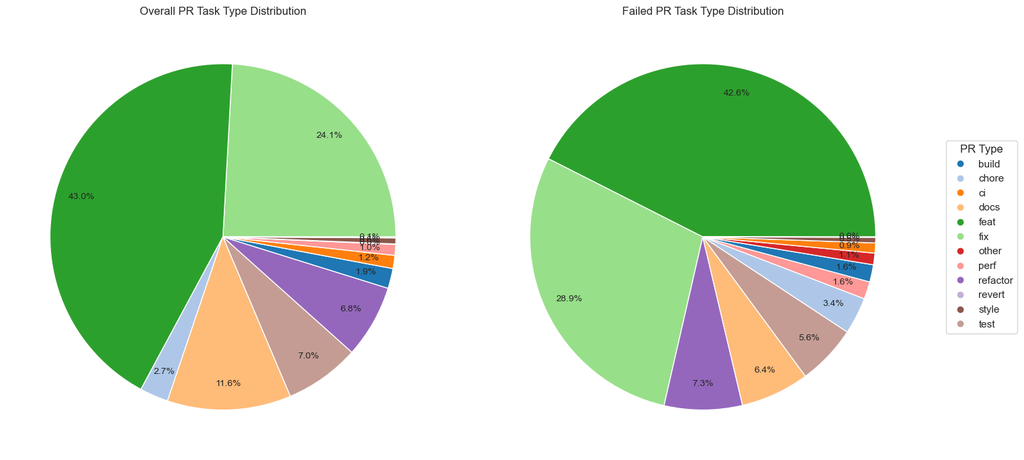

```python
pr_task_type_df = pd.read_parquet("hf://datasets/hao-li/AIDev/pr_task_type.parquet")
total_type = Counter(pr_task_type_df['type'])
fail_type = data['type'].value_counts()
all_types = sorted(set(total_type.keys()).union(set(fail_type.index)))
cmap = plt.get_cmap("tab20")
color_map = {t: cmap(i) for i, t in enumerate(all_types)}
total_colors = [color_map[t] for t in total_type.keys()]
fail_colors = [color_map[t] for t in fail_type.index]
plt.figure(figsize=(16, 7))

# Pie 1: Overall
plt.subplot(1, 2, 1)
plt.pie(
    total_type.values(),
    colors=total_colors,
    autopct='%1.1f%%',
    pctdistance=0.85,
    textprops={'fontsize': 10}
)
plt.title("Overall PR Task Type Distribution")

# Pie 2: Failed PRs
plt.subplot(1, 2, 2)
plt.pie(
    fail_type.values,
    colors=fail_colors,
    autopct='%1.1f%%',
    pctdistance=0.85,
    textprops={'fontsize': 10}
)
plt.title("Failed PR Task Type Distribution")

plt.legend(
    handles=[
        plt.Line2D([0], [0], marker='o', color=color_map[t], label=t, linestyle='')
        for t in all_types
    ],
    title="PR Type",
    bbox_to_anchor=(1.05, 0.5),
    loc="center left"
)

plt.tight_layout()
plt.show()
```

We can see from the pie chart that the docs is less likely to fail compared with other task type. But overall, the influence of job type to fail possibility is low. Therefore, we will not include it in the classification predictors.

## Step 3: Data normalization

```python
#using log to normalize over-skrewed data
for col in ["total_change", "max_change", "total_additions", "total_deletions"]:
    if col in data.columns:
        data[f"log_{col}"] = np.log1p(data[col])

#determine the predictors used for clasification, can exclude the predictors not neccessary here
feature_cols = [
    'stars',
    #'forks',
    #'type'
    "turnaround_hours",
    "commit_count",
    'review_count',
    "log_total_change",
    #"log_max_change",
    #"log_total_additions",
    "merged",
]

feature_cols = [c for c in feature_cols if c in data.columns]

X = data[feature_cols].copy()
X = X.replace([np.inf, -np.inf], np.nan).fillna(0)
```

```python
data.head()
```

|  | id_x | agent | state | created_at | closed_at | repo_id | turnaround_hours | review_count | type | commit_count | ... | total_additions | total_deletions | stars | forks | language | merged | log_total_change | log_max_change | log_total_additions | log_total_deletions |
| --- | --- | --- | --- | --- | --- | --- | --- | --- | --- | --- | --- | --- | --- | --- | --- | --- | --- | --- | --- | --- | --- |
| 0 | 3264428170 | Claude_Code | closed | 2025-07-25 21:26:37+00:00 | 2025-07-25 21:29:18+00:00 | 9.950296e+08 | 0.04 | 0 | other | 0.0 | ... | 0.0 | 0.0 | 4630.0 | 617.0 | TypeScript | False | 0.000000 | 0.000000 | 0.000000 | 0.000000 |
| 1 | 3264933329 | Claude_Code | closed | 2025-07-26 02:59:01+00:00 | 2025-07-29 07:01:20+00:00 | 1.917515e+08 | 76.04 | 0 | fix | 1.0 | ... | 394.0 | 2.0 | 1230.0 | 368.0 | Python | False | 5.983936 | 5.840642 | 5.978886 | 1.098612 |
| 2 | 3234102722 | Claude_Code | closed | 2025-07-16 01:00:34+00:00 | 2025-07-17 12:49:29+00:00 | 9.950296e+08 | 35.82 | 0 | chore | 5.0 | ... | 13214.0 | 2497.0 | 4630.0 | 617.0 | TypeScript | False | 9.662180 | 6.790097 | 9.489108 | 7.823246 |
| 3 | 3212961701 | Claude_Code | closed | 2025-07-08 15:26:38+00:00 | 2025-07-08 15:27:58+00:00 | 1.009254e+09 | 0.02 | 0 | fix | 2.0 | ... | 20716.0 | 1304.0 | 205.0 | 77.0 | Rust | False | 9.999752 | 9.595126 | 9.938710 | 7.173958 |
| 4 | 3164503419 | Claude_Code | closed | 2025-06-20 22:47:18+00:00 | 2025-06-21 11:51:22+00:00 | 1.002552e+09 | 13.07 | 2 | fix | 2.0 | ... | 1445.0 | 140.0 | 1691.0 | 106.0 | TypeScript | False | 7.368970 | 6.620073 | 7.276556 | 4.948760 |

5 rows × 23 columns

After conducting multiple experiments, we decided to exclude the variables `forks`, `log_max_change`, and `log_total_additions`. These features exhibit strong multicollinearity with existing predictors—particularly `stars` and `log_total_change`—which reduces their independent explanatory power. Removing these highly correlated variables helps prevent redundancy, stabilizes the model, and ensures more reliable interpretation of feature effects.

## Step 4: PR classification and analysis

```python
scaler = StandardScaler()
X_scaled = scaler.fit_transform(X)

n_clusters = 5
kmeans = KMeans(n_clusters=n_clusters, random_state=42, n_init="auto")
cluster_labels = kmeans.fit_predict(X_scaled)

data["cluster"] = cluster_labels
```

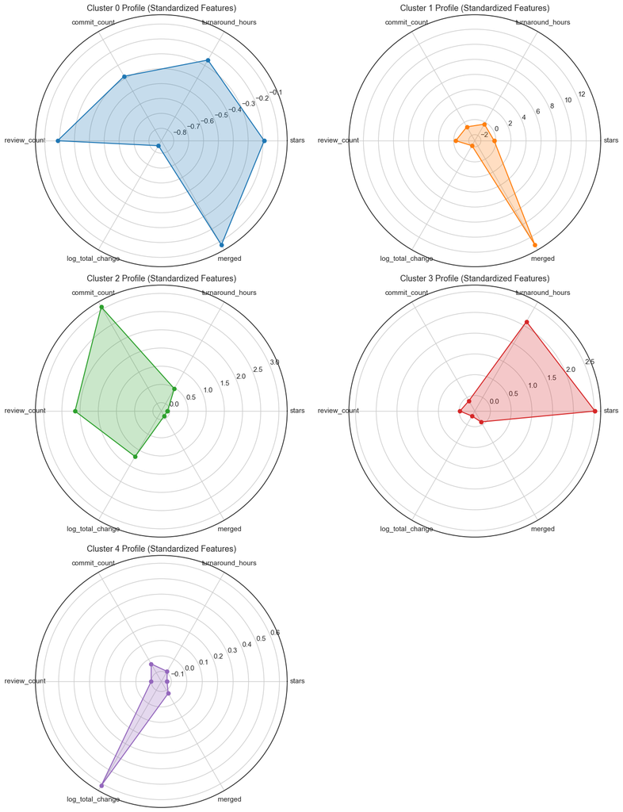

```python
X_scaled_df = pd.DataFrame(X_scaled, columns=feature_cols)
X_scaled_df["cluster"] = data["cluster"].values
cluster_means = X_scaled_df.groupby("cluster")[feature_cols].mean()

num_vars = len(feature_cols)
angles = np.linspace(0, 2 * np.pi, num_vars, endpoint=False)
angles = np.concatenate([angles, [angles[0]]])

colors = ["tab:blue", "tab:orange", "tab:green", "tab:red", "tab:purple"]

fig, axes = plt.subplots(3, 2, subplot_kw=dict(polar=True), figsize=(14, 18))

axes = axes.flatten()

for c in range(n_clusters):
    ax = axes[c]

    values = cluster_means.loc[c].values
    values = np.concatenate([values, [values[0]]])

    ax.plot(angles, values, marker="o", color=colors[c], label=f"Cluster {c}")
    ax.fill(angles, values, alpha=0.25, color=colors[c])

    ax.set_xticks(angles[:-1])
    ax.set_xticklabels(feature_cols, fontsize=11)
    ax.set_title(f"Cluster {c} Profile (Standardized Features)", fontsize=13)
    ax.grid(True)

fig.delaxes(axes[-1])

plt.tight_layout()
plt.show()
```

```python
cluster_profile = (
    data.groupby("cluster")[feature_cols]
        .median()
        .sort_index()
)

print(cluster_profile)
```

```
           stars  turnaround_hours  commit_count  review_count  \
cluster
0          609.0             1.485           1.0           0.0
1          262.0             2.765           0.0           0.0
2         1995.0           134.630          16.0           3.0
3        79404.0           581.595           2.0           0.0
4          649.0            15.970           2.0           0.0

         log_total_change  merged
cluster
0                3.332205     0.0
1                0.000000     1.0
2                7.700295     0.0
3                4.532599     0.0
4                5.961005     0.0
```

```python
print('Propertion of cluster 0 is',round(Counter(data['cluster']==0)[True]/7323,2))
print('Propertion of cluster 1 is',round(Counter(data['cluster']==1)[True]/7323,2))
print('Propertion of cluster 2 is',round(Counter(data['cluster']==2)[True]/7323,2))
print('Propertion of cluster 3 is',round(Counter(data['cluster']==3)[True]/7323,2))
print('Propertion of cluster 4 is',round(Counter(data['cluster']==4)[True]/7323,2))
```

```
Propertion of cluster 0 is 0.4
Propertion of cluster 1 is 0.01
Propertion of cluster 2 is 0.06
Propertion of cluster 3 is 0.06
Propertion of cluster 4 is 0.48
```

We categorize the failed PRs into five distinct types based on their behavioral patterns and repository characteristics:

1. **Single-commit PRs from relatively popular repositories**  
   These PRs typically have short turnaround times, as they are often reviewed and rejected quickly. Their limited commit activity suggests minimal contribution attempts before failure.
2. **Commit-less PRs from less popular repositories**  
   These PRs contain no recorded commits and represent requests opened without any substantive changes. They are frequently merged automatically after a short delay, despite not introducing meaningful contributions.
3. **Multi-commit PRs from highly popular repositories**  
   Although these PRs undergo multiple reviews and involve substantial effort, they ultimately fail to meet repository standards. This category represents fewer than 6% of all failed PRs.
4. **PRs from extremely popular repositories with heavy forking activity**  
   These repositories often maintain long review queues. As a result, PRs tend to have extended turnaround times but still end in rejection—likely due to outdated proposals or conflicts arising during delayed review cycles.
5. **Multi-commit PRs from moderately popular repositories**  
   These PRs exhibit longer turnaround times compared with Type 1 and introduce more substantial changes. Their rejection may reflect insufficient quality, misalignment with project direction, or intermediate-level review standards.

## Additional research: the fail pattern for different agent:

```python
df_ac = data[['agent', 'cluster']].copy()
count_df = (
    df_ac
    .groupby(['agent', 'cluster'])
    .size()
    .reset_index(name='count')
)
count_df['proportion'] = (
    count_df
    .groupby('agent')['count']
    .transform(lambda x: x / x.sum())
)
prop_table = count_df.pivot(index='agent', columns='cluster', values='proportion').fillna(0)
```

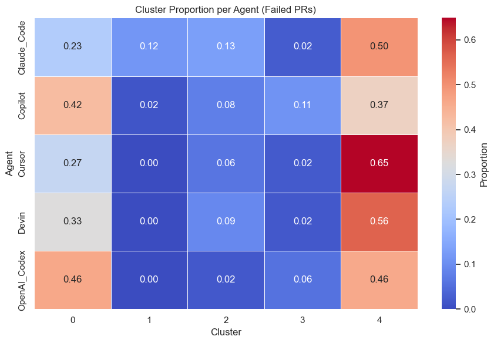

```python
plt.figure(figsize=(9, 6))
sns.set_theme(style="white")

sns.heatmap(
    prop_table,
    annot=True,
    fmt=".2f",
    cmap="coolwarm",
    linewidths=0.5,
    cbar_kws={"label": "Proportion"}
)

plt.xlabel("Cluster")
plt.ylabel("Agent")
plt.title("Cluster Proportion per Agent (Failed PRs)")
plt.tight_layout()
plt.show()
```

## Conclusion: Practical Recommendations for Improving PR Success

1. **Single-commit PRs to popular repositories**  
   These PRs fail quickly because they lack depth. Increasing **commit_count** and demonstrating more substantial **total_change** can improve perceived quality.
2. **PRs with no commit records**  
   Many of these PRs contain no actual code contribution. Ensure that the PR includes **meaningful changes** and that the repository is properly linked so commit details can be recorded.
3. **Multi-commit PRs to highly popular repositories**  
   Although these PRs show effort, they often fail due to quality issues revealed via multiple reviews. Focusing on **cleaner code**, higher **agent reliability**, and consistent **language conventions** can reduce review friction.
4. **PRs submitted to extremely high-traffic repositories**  
   These PRs often become outdated due to long review queues. Keeping the branch up-to-date, responding quickly to review requests, and reducing unnecessary changes may increase acceptance likelihood.
5. **Moderate-commit PRs to moderately popular repositories**  
   These PRs fail due to incomplete improvements. Strengthening the **total_change**, improving **code clarity**, and ensuring alignment with repository standards can help push them into the high-quality category.